# NYPD Shootings - Historical

March 2024

# Introduction

In this analysis, we explore shooting incidents that occurred in NYC from 2006 onward. The data are  
provided from the city of New York.

# Step 1

- Load required libraries.
- Download NYPD dataset and store it as nypd.

```r
library(tidyverse)
library(scales)
library(fastDummies)

nypd_url = 'https://data.cityofnewyork.us/api/views/833y-fsy8/rows.csv?accessType=DOWNLOAD'

nypd = read.csv(nypd_url)
```

# Step 2

- Show a summary of the dataset.
- Convert applicable variables to time, date, or factor.
- Remove unneeded variables.
- Examine missing values and determine how to handle them.

```r
summary(nypd)
```

```
##   INCIDENT_KEY        OCCUR_DATE         OCCUR_TIME            BORO
##  Min.   :  9953245   Length:27312       Length:27312       Length:27312
##  1st Qu.: 63860880   Class :character   Class :character   Class :character
##  Median : 90372218   Mode  :character   Mode  :character   Mode  :character
##  Mean   :120860536
##  3rd Qu.:188810230
##  Max.   :261190187
##
##  LOC_OF_OCCUR_DESC     PRECINCT      JURISDICTION_CODE LOC_CLASSFCTN_DESC
##  Length:27312       Min.   :  1.00   Min.   :0.0000    Length:27312
##  Class :character   1st Qu.: 44.00   1st Qu.:0.0000    Class :character
##  Mode  :character   Median : 68.00   Median :0.0000    Mode  :character
##                     Mean   : 65.64   Mean   :0.3269
##                     3rd Qu.: 81.00   3rd Qu.:0.0000
##                     Max.   :123.00   Max.   :2.0000
##                                      NA's   :2
##  LOCATION_DESC      STATISTICAL_MURDER_FLAG PERP_AGE_GROUP
##  Length:27312       Length:27312            Length:27312
##  Class :character   Class :character        Class :character
##  Mode  :character   Mode  :character        Mode  :character
##
##
##
##
##    PERP_SEX          PERP_RACE         VIC_AGE_GROUP        VIC_SEX
##  Length:27312       Length:27312       Length:27312       Length:27312
##  Class :character   Class :character   Class :character   Class :character
##  Mode  :character   Mode  :character   Mode  :character   Mode  :character
##
##
##
##
##    VIC_RACE           X_COORD_CD        Y_COORD_CD        Latitude
##  Length:27312       Min.   : 914928   Min.   :125757   Min.   :40.51
##  Class :character   1st Qu.:1000029   1st Qu.:182834   1st Qu.:40.67
##  Mode  :character   Median :1007731   Median :194487   Median :40.70
##                     Mean   :1009449   Mean   :208127   Mean   :40.74
##                     3rd Qu.:1016838   3rd Qu.:239518   3rd Qu.:40.82
##                     Max.   :1066815   Max.   :271128   Max.   :40.91
##                                                        NA's   :10
##    Longitude        Lon_Lat
##  Min.   :-74.25   Length:27312
##  1st Qu.:-73.94   Class :character
##  Median :-73.92   Mode  :character
##  Mean   :-73.91
##  3rd Qu.:-73.88
##  Max.   :-73.70
##  NA's   :10
```

```r
nypd_1 = nypd %>%
         select(VIC_SEX,VIC_RACE,PERP_SEX,PERP_RACE,
                STATISTICAL_MURDER_FLAG) %>%
         mutate(across(everything(), factor))

summary(nypd_1)
```

```
##  VIC_SEX                             VIC_RACE       PERP_SEX
##  F: 2615   AMERICAN INDIAN/ALASKAN NATIVE:   10         : 9310
##  M:24686   ASIAN / PACIFIC ISLANDER      :  404   (null):  640
##  U:   11   BLACK                         :19439   F     :  424
##            BLACK HISPANIC                : 2646   M     :15439
##            UNKNOWN                       :   66   U     : 1499
##            WHITE                         :  698
##            WHITE HISPANIC                : 4049
##           PERP_RACE     STATISTICAL_MURDER_FLAG
##  BLACK         :11432   false:22046
##                : 9310   true : 5266
##  WHITE HISPANIC: 2341
##  UNKNOWN       : 1836
##  BLACK HISPANIC: 1314
##  (null)        :  640
##  (Other)       :  439
```

Missing Values: PERP_SEX and PERP_RACE have a high proportion of nulls, unknown, or blanks. There is no obvious way to impute them, so I’ll recode them to missing. They will be included in the descriptive analyses but drop out of the models.

```r
nypd_2 =  nypd_1 %>%
  mutate(PERP_SEX = factor(case_when(PERP_SEX %in% c("(null)","","U") ~                                    NA,.default=PERP_SEX))) %>%
  mutate(PERP_RACE = factor(case_when(PERP_RACE %in% c("(null)","","UNKNOWN") ~ NA                                     ,.default=PERP_RACE)))

summary(nypd_2)
```

```
##  VIC_SEX                             VIC_RACE     PERP_SEX
##  F: 2615   AMERICAN INDIAN/ALASKAN NATIVE:   10   F   :  424
##  M:24686   ASIAN / PACIFIC ISLANDER      :  404   M   :15439
##  U:   11   BLACK                         :19439   NA's:11449
##            BLACK HISPANIC                : 2646
##            UNKNOWN                       :   66
##            WHITE                         :  698
##            WHITE HISPANIC                : 4049
##                           PERP_RACE     STATISTICAL_MURDER_FLAG
##  AMERICAN INDIAN/ALASKAN NATIVE:    2   false:22046
##  ASIAN / PACIFIC ISLANDER      :  154   true : 5266
##  BLACK                         :11432
##  BLACK HISPANIC                : 1314
##  WHITE                         :  283
##  WHITE HISPANIC                : 2341
##  NA's                          :11786
```

# Step 3

- Create visualizations and conduct analysis.

# Descriptive statistics

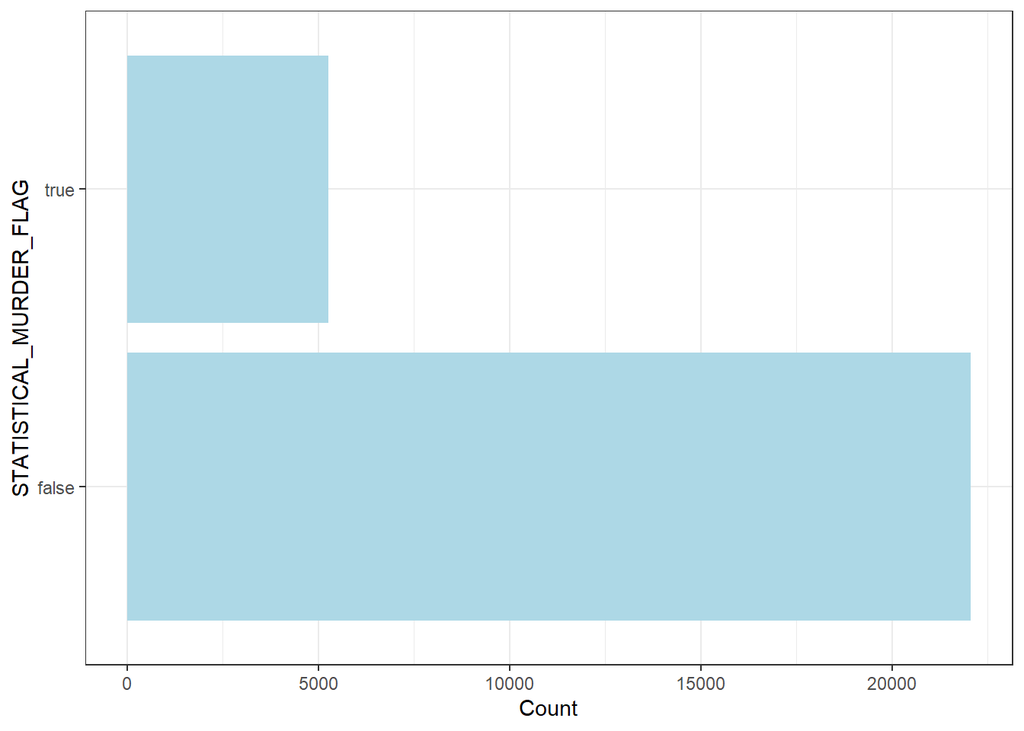

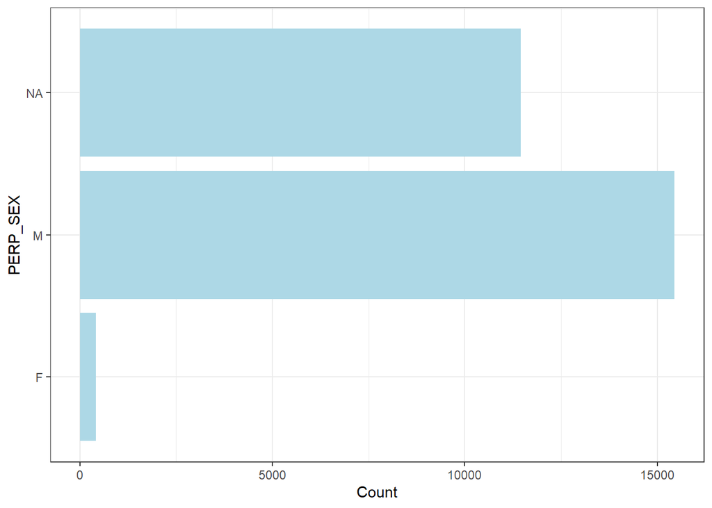

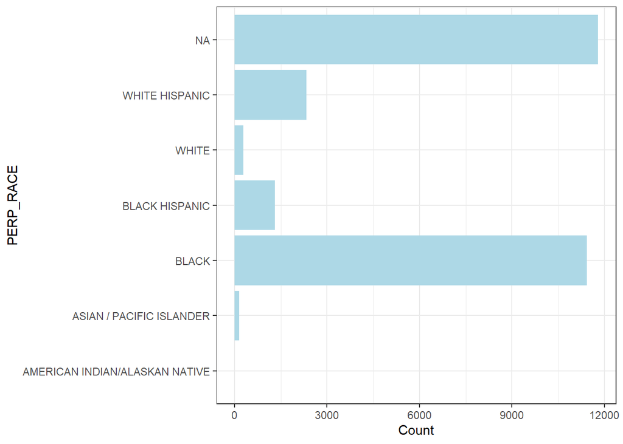

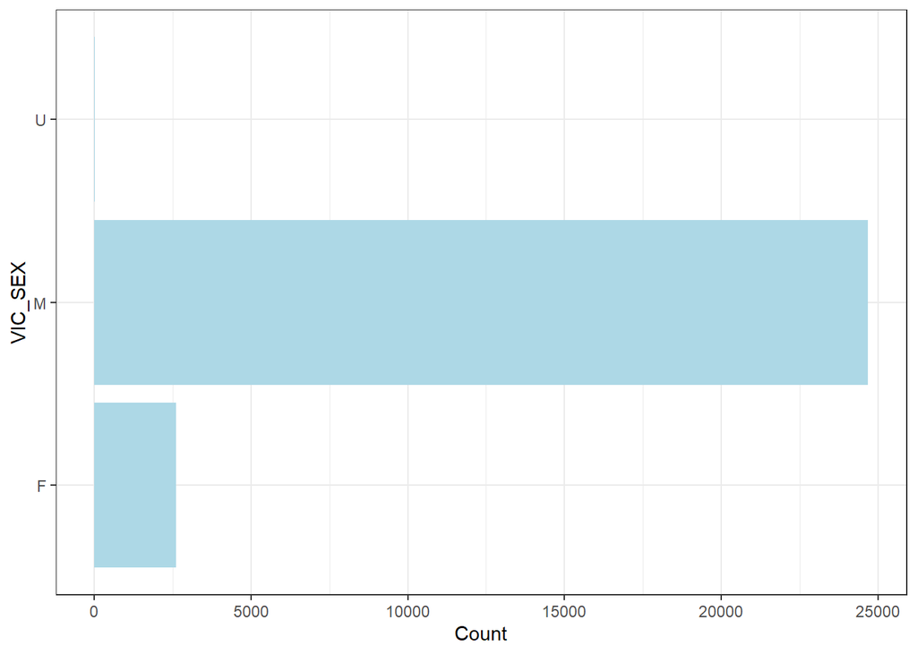

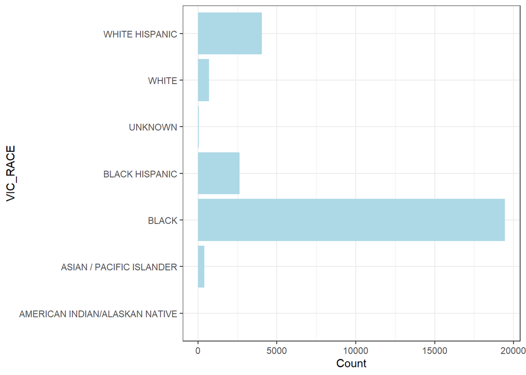

```r
for (x in c('STATISTICAL_MURDER_FLAG',
            'PERP_SEX','PERP_RACE','VIC_SEX',
            'VIC_RACE')){
p = nypd_2 %>%
  count(Value=get(x),name = "Count") %>%
  ggplot() +

  geom_col(aes(Count,Value),fill='lightblue') +
  ylab(x)+
  theme_bw()

print(p)
}
```

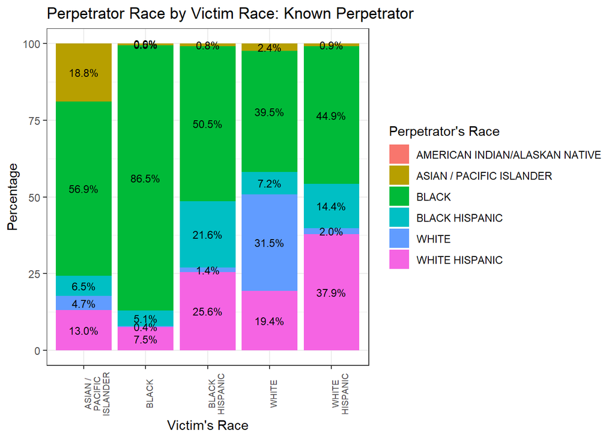

```r
q1 = nypd_2 %>%
  group_by(VIC_RACE) %>%
  filter(n()>100 & !is.na(PERP_RACE)) %>%
  count(VIC_RACE, PERP_RACE) %>%
  mutate(Percentage = prop.table(n) * 100) %>%
  ggplot(aes(x=VIC_RACE, y=Percentage, fill=PERP_RACE)) +
  geom_bar(stat="identity") +
  ylab("Percentage") +
  xlab("Victim's Race")+
  labs(fill="Perpetrator's Race") +
  scale_x_discrete(label=label_wrap(10))+
  geom_text(aes(label=paste0(sprintf("%1.1f", Percentage),"%")),
            position=position_stack(vjust=0.5),size=3) +
  ggtitle("Perpetrator Race by Victim Race: Known Perpetrator") +
  theme_bw() +
  theme(axis.text.x=element_text(angle = 90,size = 7, hjust = .5))

print(q1)
```

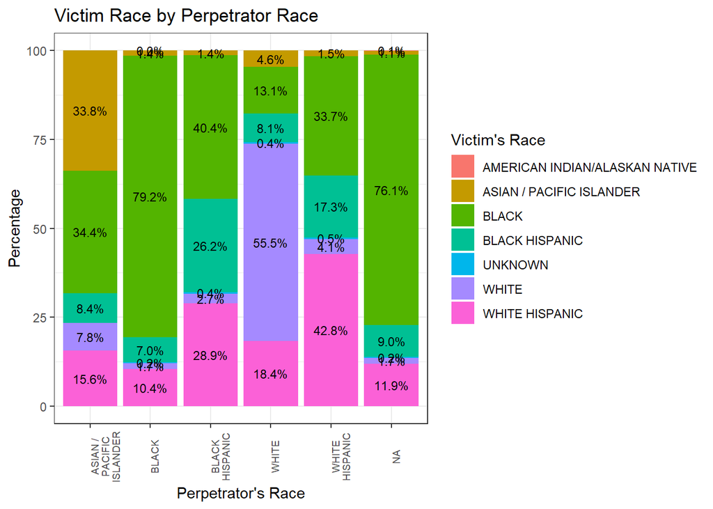

```r
q2 = nypd_2 %>%
  group_by(PERP_RACE) %>%
  filter(n()>100) %>%
  count(VIC_RACE, PERP_RACE) %>%
  mutate(Percentage = prop.table(n) * 100) %>%
  ggplot(aes(fill = VIC_RACE, y=Percentage, x=PERP_RACE)) +
  geom_bar(stat="identity") +
  ylab("Percentage") +
  labs(fill="Victim's Race")+
  xlab("Perpetrator's Race") +
  scale_x_discrete(label=label_wrap(10))+
  geom_text(aes(label=paste0(sprintf("%1.1f", Percentage),"%")),
            position=position_stack(vjust=0.5),size=3) +
  ggtitle("Victim Race by Perpetrator Race") +
  theme_bw() +
  theme(axis.text.x=element_text(angle = 90,size = 7, hjust = .5))

print(q2)
```

Conclusion: The graphs show most victims were black, with perpetrators who were black or of an unknown race. I want to look more about the interaction between races and which shootings were classified as murder.

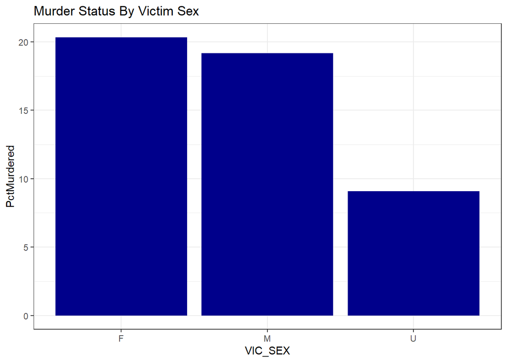

```r
g = nypd_2 %>%
  group_by(VIC_SEX) %>%
  summarise(PctMurdered = sum(STATISTICAL_MURDER_FLAG == "true")/n()*100) %>%
  ggplot() +

  geom_bar(aes(x=VIC_SEX,y=PctMurdered),
           fill="darkblue",stat="identity") +
  theme_bw()+
  ggtitle('Murder Status By Victim Sex')

print(g)
```

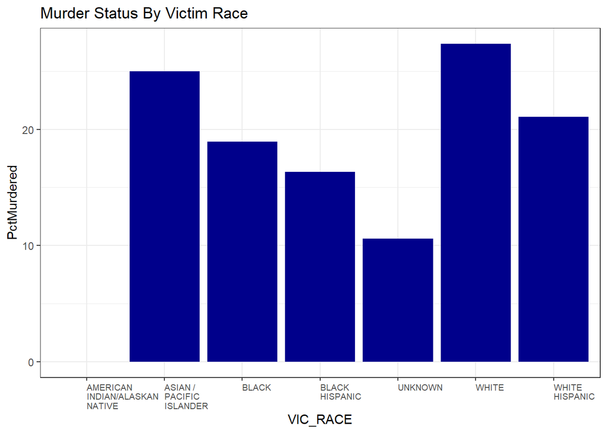

```r
g = nypd_2 %>%
  group_by(VIC_RACE) %>%
  summarise(PctMurdered= sum(STATISTICAL_MURDER_FLAG == "true")/n()*100) %>%
  ggplot() +
  scale_x_discrete(label=label_wrap(10))+
  geom_bar(aes(x=VIC_RACE,y=PctMurdered),
           fill="darkblue",stat="identity") +
  theme_bw() +
  theme(axis.text.x=element_text(angle = 0,size = 7,hjust = 0)) +
  ggtitle('Murder Status By Victim Race')

print(g)
```

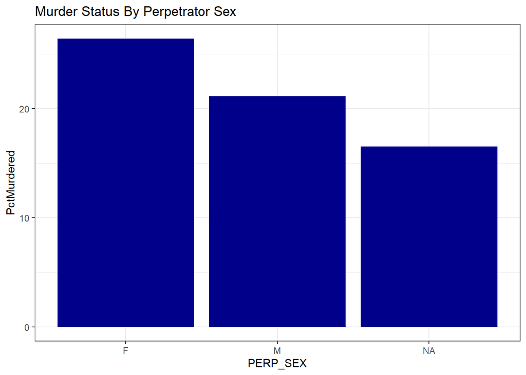

```r
g = nypd_2 %>%
  group_by(PERP_SEX) %>%
  summarise(PctMurdered = sum(STATISTICAL_MURDER_FLAG == "true")/n()*100) %>%
  ggplot() +
  geom_bar(aes(x=PERP_SEX,y=PctMurdered),
           fill="darkblue",stat="identity") +
  theme_bw()+
  ggtitle('Murder Status By Perpetrator Sex')

print(g)
```

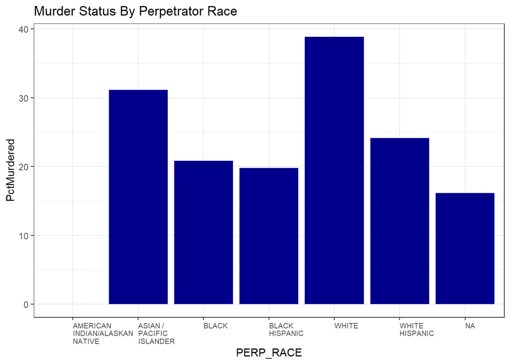

```r
g = nypd_2%>%
  group_by(PERP_RACE) %>%
  summarise(PctMurdered= sum(STATISTICAL_MURDER_FLAG == "true")/n()*100) %>%
  ggplot() +
  scale_x_discrete(label=label_wrap(10))+
  geom_bar(aes(x=PERP_RACE,y=PctMurdered),
           fill="darkblue",stat="identity") +
  theme_bw() +
  theme(axis.text.x=element_text(angle = 0,size = 7,hjust = 0)) +
  ggtitle('Murder Status By Perpetrator Race')

print(g)
```

## Inferential statistics

- Use the fastDummies package to create dummy variables.

```r
nypd_3 =  nypd_2 %>%
  fastDummies::dummy_cols(select_column=c('STATISTICAL_MURDER_FLAG','VIC_RACE',"VIC_SEX","PERP_RACE","PERP_SEX"))
names(nypd_3)
```

```
##  [1] "VIC_SEX"
##  [2] "VIC_RACE"
##  [3] "PERP_SEX"
##  [4] "PERP_RACE"
##  [5] "STATISTICAL_MURDER_FLAG"
##  [6] "STATISTICAL_MURDER_FLAG_false"
##  [7] "STATISTICAL_MURDER_FLAG_true"
##  [8] "VIC_RACE_AMERICAN INDIAN/ALASKAN NATIVE"
##  [9] "VIC_RACE_ASIAN / PACIFIC ISLANDER"
## [10] "VIC_RACE_BLACK"
## [11] "VIC_RACE_BLACK HISPANIC"
## [12] "VIC_RACE_UNKNOWN"
## [13] "VIC_RACE_WHITE"
## [14] "VIC_RACE_WHITE HISPANIC"
## [15] "VIC_SEX_F"
## [16] "VIC_SEX_M"
## [17] "VIC_SEX_U"
## [18] "PERP_RACE_AMERICAN INDIAN/ALASKAN NATIVE"
## [19] "PERP_RACE_ASIAN / PACIFIC ISLANDER"
## [20] "PERP_RACE_BLACK"
## [21] "PERP_RACE_BLACK HISPANIC"
## [22] "PERP_RACE_WHITE"
## [23] "PERP_RACE_WHITE HISPANIC"
## [24] "PERP_RACE_NA"
## [25] "PERP_SEX_F"
## [26] "PERP_SEX_M"
## [27] "PERP_SEX_NA"
```

- Run model of STATISTICAL_MURDER_FLAG as a fuction of VICTIM_RACE and VICTIM_SEX.

```r
g1 = glm(STATISTICAL_MURDER_FLAG_true ~
            VIC_RACE_WHITE + VIC_SEX_F ,
         family=binomial(link='logit'),nypd_3 %>%
           filter(PERP_RACE_NA == 0 | PERP_SEX_NA == 0)
         )
summary(g1)
```

```
##
## Call:
## glm(formula = STATISTICAL_MURDER_FLAG_true ~ VIC_RACE_WHITE +
##     VIC_SEX_F, family = binomial(link = "logit"), data = nypd_3 %>%
##     filter(PERP_RACE_NA == 0 | PERP_SEX_NA == 0))
##
## Coefficients:
##                Estimate Std. Error z value Pr(>|z|)
## (Intercept)    -1.34267    0.02099 -63.967  < 2e-16 ***
## VIC_RACE_WHITE  0.40214    0.09984   4.028 5.63e-05 ***
## VIC_SEX_F       0.15963    0.06001   2.660  0.00781 **
## ---
## Signif. codes:  0 '***' 0.001 '**' 0.01 '*' 0.05 '.' 0.1 ' ' 1
##
## (Dispersion parameter for binomial family taken to be 1)
##
##     Null deviance: 16431  on 15882  degrees of freedom
## Residual deviance: 16407  on 15880  degrees of freedom
## AIC: 16413
##
## Number of Fisher Scoring iterations: 4
```

```r
exp(coef(g1))
```

```
##    (Intercept) VIC_RACE_WHITE      VIC_SEX_F
##      0.2611477      1.4950257      1.1730821
```

Controlling for gender, shootings for which the victims are white are nearly 50% more likely to be classified as murder as for victims that are not white.

Controlling for race, shootings for which the victims are female are 17% more likely to be classified as murder as for victims that are male.

```r
g2 = glm(STATISTICAL_MURDER_FLAG_true ~
           PERP_RACE_WHITE + PERP_SEX_F ,
         family=binomial(link='logit'),nypd_3 %>%
           filter(PERP_RACE_NA == 0 | PERP_SEX_NA == 0)
)
summary(g2)
```

```
##
## Call:
## glm(formula = STATISTICAL_MURDER_FLAG_true ~ PERP_RACE_WHITE +
##     PERP_SEX_F, family = binomial(link = "logit"), data = nypd_3 %>%
##     filter(PERP_RACE_NA == 0 | PERP_SEX_NA == 0))
##
## Coefficients:
##                 Estimate Std. Error z value Pr(>|z|)
## (Intercept)     -1.31097    0.02007 -65.323  < 2e-16 ***
## PERP_RACE_WHITE  0.84119    0.12367   6.802 1.03e-11 ***
## PERP_SEX_F       0.26081    0.11263   2.316   0.0206 *
## ---
## Signif. codes:  0 '***' 0.001 '**' 0.01 '*' 0.05 '.' 0.1 ' ' 1
##
## (Dispersion parameter for binomial family taken to be 1)
##
##     Null deviance: 16212  on 15505  degrees of freedom
## Residual deviance: 16163  on 15503  degrees of freedom
##   (377 observations deleted due to missingness)
## AIC: 16169
##
## Number of Fisher Scoring iterations: 4
```

```r
exp(coef(g2))
```

```
##     (Intercept) PERP_RACE_WHITE      PERP_SEX_F
##       0.2695572       2.3191303       1.2979872
```

Controlling for gender, shootings for which the perpetrators are white are over twice as likely to be classified as murder as for perpetrators that are not white.

Controlling for race, shootings for which the perpetrators are female are 30% more likely to be classified as murder as for perpetrators that are male.

# Step 4

In this analysis, we explored shooting incidents in NYC. We found that most shootings involved black victims and black perpetrators. Victims and perpetrators were also more likely to be male.

We analyzed the likelihood that the shootings were classified as murder. They were more likely to be so if the victim was white or female or if the perpetrator was white or female.

We need to be aware of the researcher’s potential bias and the data’s potential bias. I’ve identified several sources of potential bias in the data to be aware of.

1. Many records did not include the race or sex of the perpetrator. This limits the results, as there could be systematic reasons why some crimes don’t have a known perpetrator,
2. There isn’t a way to know which fatal shootings are appropriately classified as murder or not. There may be pressure on law enforcement or prosecutors to charge that one way or another based on the circumstances or the individuals involved.

# Notes

- I used Internet resources including Stackoverflow.com and bookdown.com to assist in producing this R code.